# Statistical Rethinking (Code)

Chapter 8

March, 2017

Code from *Statistical Rethinking* modified by R Pruim is shown below. Differences to the oringal include:

- a preference for putting data into containers (data frames, mostly), rather than working with lose vectors.
- use of `ggplot2` (via `ggformula`) rather than base graphics
- use of `tidyverse` for data transformation
- better (in my opinion) naming conventions

#### R Code 8.1

The book does this as a chunk of code. It is much nicer to wrap this in a function and to return a data frame that makes plotting nicer.

```r
KingMarkov <- function(
  num_steps = 1e5,
  population = 1:10,
  start = 10) {

  num_islands <- length(population)
  position <- rep(NA, num_steps)  # trick to pre-alocate memory
  current <- start

  for (i in 1:num_steps) {
    # record current position
    position[i] <- current

    # flip coin to generate proposal
    proposal <- 1 + (current + sample(c(-2, 0), size = 1) ) %% 10

    # move?
    prob_move <- population[proposal] / population[current]
    current <- ifelse(runif(1) < prob_move, proposal, current)
  }
  data_frame(
    step = 1:num_steps,
    position = position
  )
}
```

In the short-run, any particular path looks like a jumble, and the desired probabilities are not acheived.

```r
set.seed(100)
KM <- KingMarkov(100)
gf_point(position ~ step, data = KM)
tally( ~ position, data = KM)
```

```
## position
##  4  5  6  7  8  9 10
##  1  3  9 28 28 15 16
```

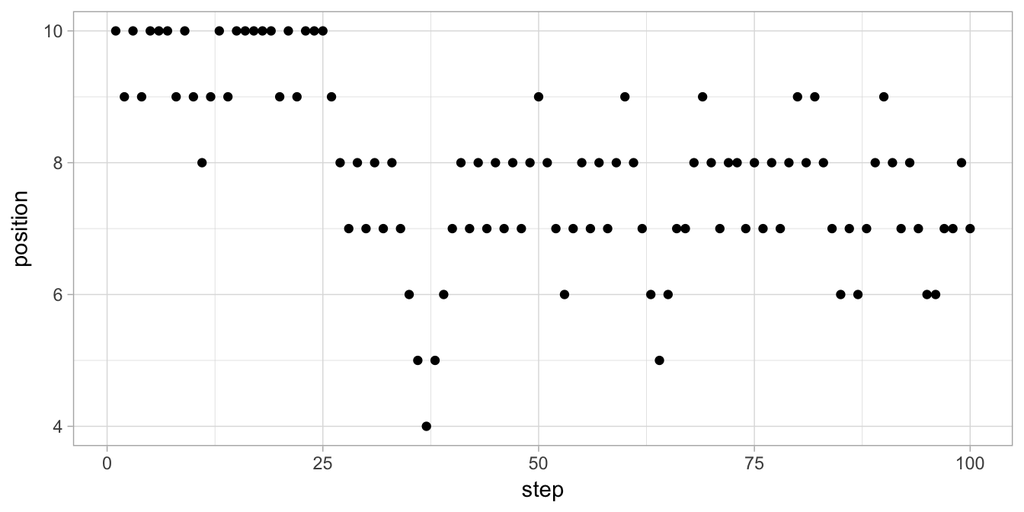

With a larger number of steps, things are still not perfect, but the are much closer to the target probabilities.

```
## # A tibble: 10 × 4
##    position     n    prop     target
##       <dbl> <int>   <dbl>      <dbl>
## 1         1  1813 0.01813 0.01818182
## 2         2  3658 0.03658 0.03636364
## 3         3  5316 0.05316 0.05454545
## 4         4  7193 0.07193 0.07272727
## 5         5  9118 0.09118 0.09090909
## 6         6 11030 0.11030 0.10909091
## 7         7 12889 0.12889 0.12727273
## 8         8 14772 0.14772 0.14545455
## 9         9 16426 0.16426 0.16363636
## 10       10 17785 0.17785 0.18181818
```

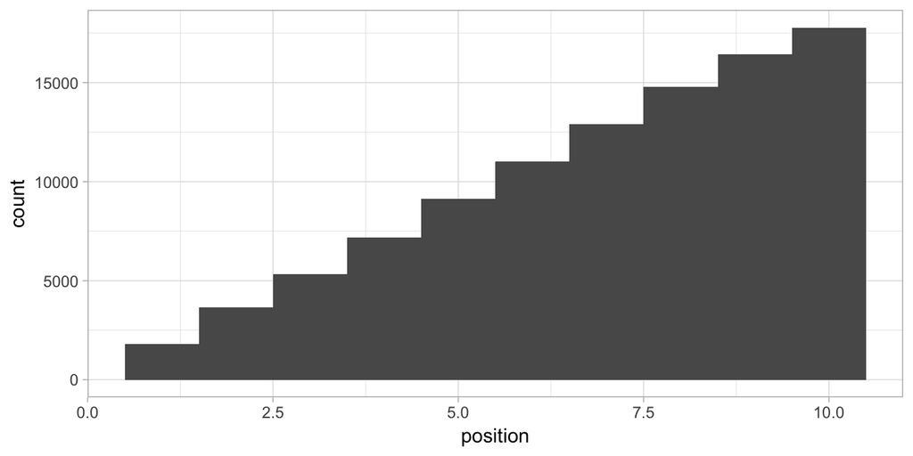

```r
set.seed(123)
KM <- KingMarkov(1e5)
gf_histogram( ~ position, data = KM, binwidth = 1)
KM %>%
  group_by(position) %>%
  summarise(n = n(), prop = n / 1e5) %>%
  mutate(target = (1:10)/(sum(1:10)))
```

Alternatively, we can propose any island instead of just neighboring islands.

```r
KingMarkov2 <- function(
  num_steps = 1e5,
  population = 1:10,
  start = 10) {

  num_islands <- length(population)
  position <- rep(NA, num_steps)  # trick to pre-alocate memory
  current <- start

  for (i in 1:num_steps) {
    # record current position
    position[i] <- current

    # propose any one of the other islands
    proposal <- sample(setdiff(1:num_islands, current), 1)

    # move?
    prob_move <- population[proposal] / population[current]
    current <- ifelse(runif(1) < prob_move, proposal, current)
  }
  data_frame(
    step = 1:num_steps,
    position = position
  )
}
```

The mixing is faster now.

```r
set.seed(100)
KM2 <- KingMarkov2(100)
gf_point(position ~ step, data = KM2)
tally( ~ position, data = KM2)
```

```
## position
##  1  2  3  4  5  6  7  8  9 10
##  1  4  5  7 12 12  9 15 11 24
```

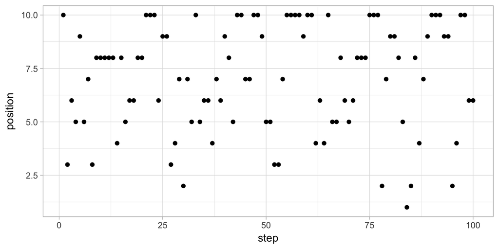

With a larger number of steps, things are still not perfect, but the are much closer to the target probabilities.

```
## # A tibble: 10 × 4
##    position     n    prop     target
##       <dbl> <int>   <dbl>      <dbl>
## 1         1  1798 0.01798 0.01818182
## 2         2  3578 0.03578 0.03636364
## 3         3  5587 0.05587 0.05454545
## 4         4  7158 0.07158 0.07272727
## 5         5  9146 0.09146 0.09090909
## 6         6 10768 0.10768 0.10909091
## 7         7 12917 0.12917 0.12727273
## 8         8 14467 0.14467 0.14545455
## 9         9 16315 0.16315 0.16363636
## 10       10 18266 0.18266 0.18181818
```

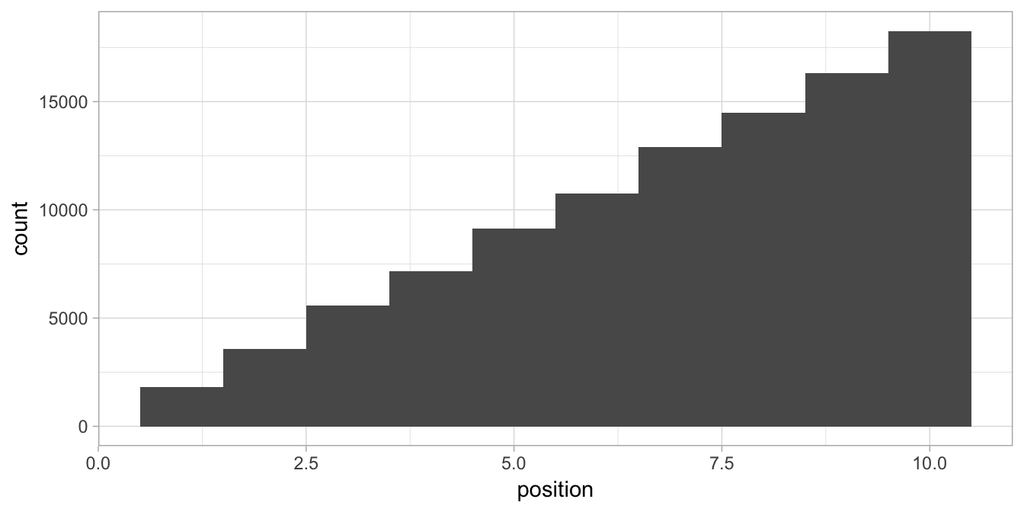

```r
set.seed(123)
KM2 <- KingMarkov2(1e5)
gf_histogram( ~ position, data = KM2, binwidth = 1)
KM2 %>%
  group_by(position) %>%
  summarise(n = n(), prop = n / 1e5) %>%
  mutate(target = (1:10)/(sum(1:10)))
```

#### R Code 8.2

```r
library(rethinking)
data(rugged)
Nations <- rugged %>%
  mutate(log_gdp = log(rgdppc_2000)) %>%
  filter(!is.na(rgdppc_2000))
```

#### R Code 8.3

```r
m8.1 <- map(
  alist(
    log_gdp ~ dnorm(mu, sigma),
    mu <- a + bR * rugged + bA * cont_africa + bAR * rugged * cont_africa,
    a ~ dnorm(0, 100),
    bR ~ dnorm(0, 10),
    bA ~ dnorm(0, 10),
    bAR ~ dnorm(0, 10),
    sigma ~ dunif(0, 10)
  ),
  data = Nations
)
precis(m8.1)
```

```
##        Mean StdDev  5.5% 94.5%
## a      9.22   0.14  9.00  9.44
## bR    -0.20   0.08 -0.32 -0.08
## bA    -1.95   0.22 -2.31 -1.59
## bAR    0.39   0.13  0.19  0.60
## sigma  0.93   0.05  0.85  1.01
```

#### R Code 8.4

Restrict to 3 variables

```r
inspect(Nations)   # Note: several variables have missing values
```

```
##
## categorical variables:
##      name  class levels   n missing
## 1 isocode factor    234 170       0
## 2 country factor    234 170       0
##                                    distribution
## 1 AGO (0.6%), ALB (0.6%), ARE (0.6%) ...
## 2 Albania (0.6%), Algeria (0.6%) ...
##
## quantitative variables:
##                      name   class         min           Q1        median
## 1                  isonum integer    8.000000   212.500000    417.500000
## 2                  rugged numeric    0.003000     0.442250      0.979500
## 3             rugged_popw numeric    0.003000     0.283000      0.579500
## 4            rugged_slope numeric    0.005000     1.287750      2.792500
```

[output cut: 97 more lines]

```r
Nations.trim <- Nations %>% select(log_gdp, rugged, cont_africa)
inspect(Nations.trim)  # No missing values among these three variables
```

```
##
## quantitative variables:
##          name   class      min       Q1   median       Q3      max
## 1     log_gdp numeric 6.145573 7.539468 8.578233 9.480244 10.96461
## 2      rugged numeric 0.003000 0.442250 0.979500 1.957250  6.20200
## 3 cont_africa integer 0.000000 0.000000 0.000000 1.000000  1.00000
##        mean        sd   n missing
## 1 8.5171175 1.1664946 170       0
## 2 1.3331824 1.1684674 170       0
## 3 0.2882353 0.4542793 170       0
```

Fit with Stan:

```r
m8.1stan <- map2stan(
  alist(
    log_gdp ~ dnorm(mu, sigma),
    mu <- a + bR * rugged + bA * cont_africa + bAR * rugged * cont_africa,
    a ~ dnorm(0, 100),
    bR ~ dnorm(0, 10),
    bA ~ dnorm(0, 10),
    bAR ~ dnorm(0, 10),
    sigma ~ dcauchy(0, 2)
  ),
  data = Nations.trim,
  refresh = 0
)
```

#### R Code 8.6

```r
show(m8.1stan)
```

```
## map2stan model fit
## 1000 samples from 1 chain
##
## Formula:
## log_gdp ~ dnorm(mu, sigma)
## mu <- a + bR * rugged + bA * cont_africa + bAR * rugged * cont_africa
## a ~ dnorm(0, 100)
## bR ~ dnorm(0, 10)
## bA ~ dnorm(0, 10)
## bAR ~ dnorm(0, 10)
## sigma ~ dcauchy(0, 2)
##
## Log-likelihood at expected values: -229.45
## Deviance: 458.9
## DIC: 468.52
## Effective number of parameters (pD): 4.81
##
## WAIC (SE): 468.9 (14.8)
## pWAIC: 4.87
```

```r
precis(m8.1stan)
```

```
##        Mean StdDev lower 0.89 upper 0.89 n_eff Rhat
## a      9.24   0.14       9.02       9.45   376    1
## bR    -0.21   0.08      -0.32      -0.08   449    1
## bA    -1.97   0.21      -2.29      -1.62   493    1
## bAR    0.41   0.13       0.22       0.62   493    1
## sigma  0.95   0.05       0.86       1.03   468    1
```

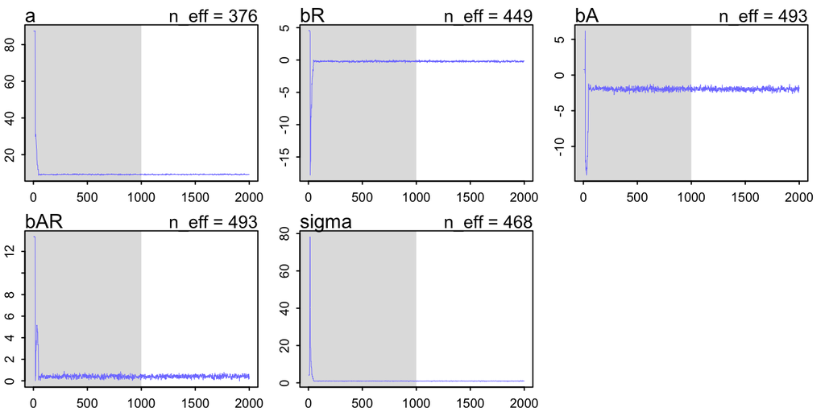

```r
plot(m8.1stan)
```

#### R Code 8.7

```r
m8.1stan_4chains <- map2stan(m8.1stan, chains = 4, cores = 4)
```

[output not shown]

```
## Computing WAIC
```

```
## Constructing posterior predictions
```

[output not shown]

```r
precis(m8.1stan_4chains)
```

```
##        Mean StdDev lower 0.89 upper 0.89 n_eff Rhat
## a      9.22   0.14       9.00       9.45  1762    1
## bR    -0.20   0.08      -0.32      -0.07  1678    1
## bA    -1.95   0.23      -2.35      -1.61  1796    1
## bAR    0.39   0.13       0.19       0.60  1803    1
## sigma  0.95   0.05       0.86       1.03  3032    1
```

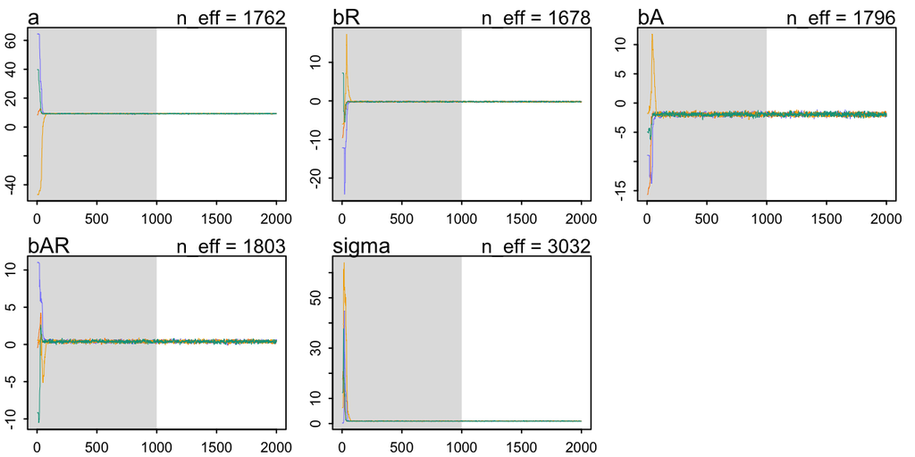

```r
plot(m8.1stan_4chains)
```

#### R Code 8.8

```r
m8.1s.post <- extract.samples(m8.1stan)
str(m8.1s.post)
```

```
## List of 5
##  $ a    : num [1:1000(1d)] 9.3 9.17 9.37 9.05 9.21 ...
##  $ bR   : num [1:1000(1d)] -0.224 -0.167 -0.307 -0.113 -0.198 ...
##  $ bA   : num [1:1000(1d)] -1.98 -2.04 -2.21 -1.63 -2.09 ...
##  $ bAR  : num [1:1000(1d)] 0.445 0.363 0.586 0.193 0.516 ...
##  $ sigma: num [1:1000(1d)] 0.959 0.881 0.92 0.912 0.961 ...
```

```r
str(m8.1s.post %>% as.data.frame())
```

```
## 'data.frame':    1000 obs. of  5 variables:
##  $ a    : num [1:1000(1d)] 9.3 9.17 9.37 9.05 9.21 ...
##  $ bR   : num [1:1000(1d)] -0.224 -0.167 -0.307 -0.113 -0.198 ...
##  $ bA   : num [1:1000(1d)] -1.98 -2.04 -2.21 -1.63 -2.09 ...
##  $ bAR  : num [1:1000(1d)] 0.445 0.363 0.586 0.193 0.516 ...
##  $ sigma: num [1:1000(1d)] 0.959 0.881 0.92 0.912 0.961 ...
```

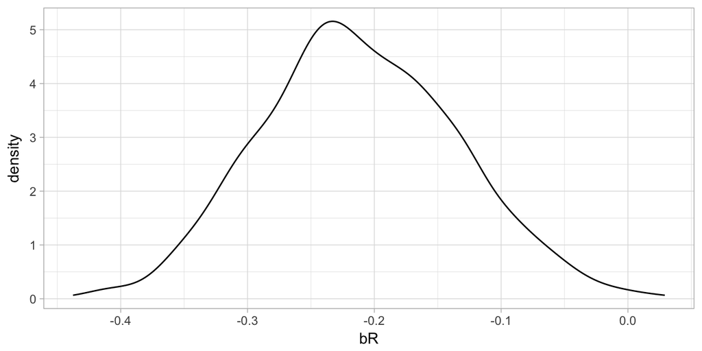

```r
gf_dens(~ bR, data = m8.1s.post %>% as.data.frame())
```

#### R Code 8.9

The `rethinking` package includes methods for `pairs()`.

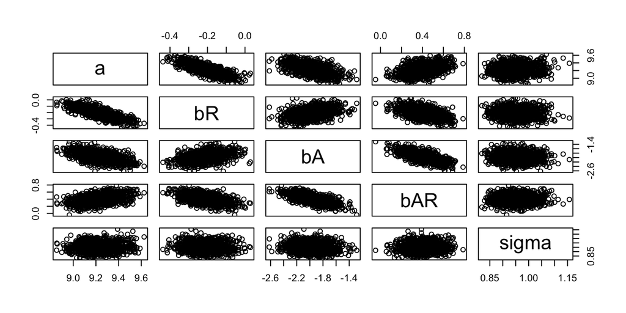

```r
pairs(m8.1s.post)
```

#### R Code 8.10

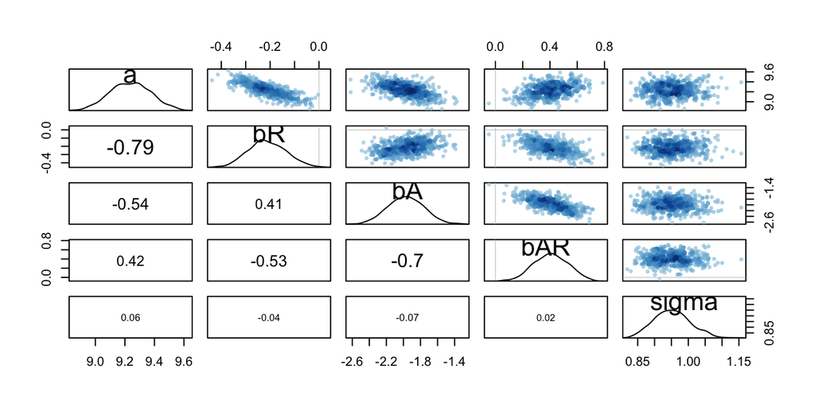

```r
pairs(m8.1stan)
```

#### R Code 8.11

```r
show(m8.1stan)
```

```
## map2stan model fit
## 1000 samples from 1 chain
##
## Formula:
## log_gdp ~ dnorm(mu, sigma)
## mu <- a + bR * rugged + bA * cont_africa + bAR * rugged * cont_africa
## a ~ dnorm(0, 100)
## bR ~ dnorm(0, 10)
## bA ~ dnorm(0, 10)
## bAR ~ dnorm(0, 10)
## sigma ~ dcauchy(0, 2)
##
## Log-likelihood at expected values: -229.45
## Deviance: 458.9
## DIC: 468.52
## Effective number of parameters (pD): 4.81
##
## WAIC (SE): 468.9 (14.8)
## pWAIC: 4.87
```

#### R Code 8.12

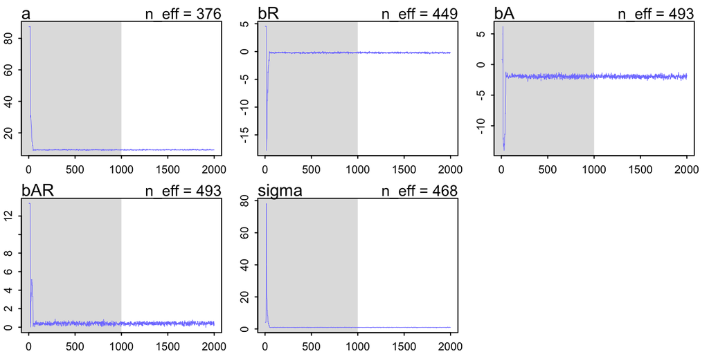

```r
plot(m8.1stan)
```

Want to see raw Stan code? Here it is.

```r
stancode(m8.1stan)
```

```
## data{
##     int<lower=1> N;
##     real log_gdp[N];
##     real rugged[N];
##     int cont_africa[N];
## }
## parameters{
##     real a;
##     real bR;
##     real bA;
##     real bAR;
##     real<lower=0> sigma;
## }
## model{
##     vector[N] mu;
##     sigma ~ cauchy( 0 , 2 );
##     bAR ~ normal( 0 , 10 );
##     bA ~ normal( 0 , 10 );
##     bR ~ normal( 0 , 10 );
##     a ~ normal( 0 , 100 );
##     for ( i in 1:N ) {
##         mu[i] = a + bR * rugged[i] + bA * cont_africa[i] + bAR * rugged[i] * cont_africa[i];
##     }
##     log_gdp ~ normal( mu , sigma );
## }
## generated quantities{
##     vector[N] mu;
##     real dev;
##     dev = 0;
##     for ( i in 1:N ) {
##         mu[i] = a + bR * rugged[i] + bA * cont_africa[i] + bAR * rugged[i] * cont_africa[i];
##     }
##     dev = dev + (-2)*normal_lpdf( log_gdp | mu , sigma );
## }
```

#### R Code 8.13

```r
y <- c(-1, 1)
m8.2 <- map2stan(
  alist(y ~ dnorm(mu, sigma),
        mu <- alpha),
  data = list(y = y),
  start = list(alpha = 0, sigma = 1),
  chains = 2, cores = 2,
  iter = 4000, warmup = 1000
)
```

[output not shown]

```
## Computing WAIC
```

```
## Constructing posterior predictions
```

[output not shown]

#### R Code 8.14

```r
precis(m8.2)
```

```
##           Mean    StdDev  lower 0.89 upper 0.89 n_eff Rhat
## alpha  1174967   3438009 -1771670.19    8980565    14  1.1
## sigma 12053381 108539021      350.03   15853582   515  1.0
```

```
## data{
##     int<lower=1> N;
##     real y[N];
## }
## parameters{
##     real alpha;
##     real<lower=0> sigma;
## }
## model{
##     vector[N] mu;
##     for ( i in 1:N ) {
##         mu[i] = alpha;
##     }
##     y ~ normal( mu , sigma );
## }
## generated quantities{
##     vector[N] mu;
##     real dev;
##     dev = 0;
##     for ( i in 1:N ) {
##         mu[i] = alpha;
##     }
##     dev = dev + (-2)*normal_lpdf( y | mu , sigma );
## }
```

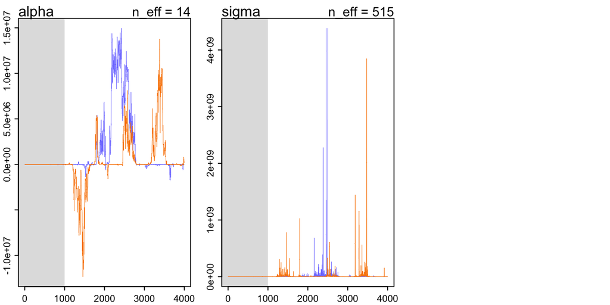

```r
plot(m8.2)
stancode(m8.2)
```

#### R Code 8.15

```r
m8.3 <- map2stan(
  alist(
    y ~ dnorm(mu, sigma),
    mu <- alpha,
    alpha ~ dnorm(1, 10),
    sigma ~ dcauchy(0, 1)
  ),
  data = list(y = y),
  start = list(alpha = 0, sigma = 1),
  chains = 2,
  iter = 4000,
  warmup = 1000
)
```

[output not shown]

```
## Computing WAIC
```

```
## Constructing posterior predictions
```

[output not shown]

```r
precis(m8.3)
```

```
##       Mean StdDev lower 0.89 upper 0.89 n_eff Rhat
## alpha 0.08   1.81      -2.29       2.47  1181    1
## sigma 2.07   2.04       0.45       3.61   934    1
```

#### R Code 8.16

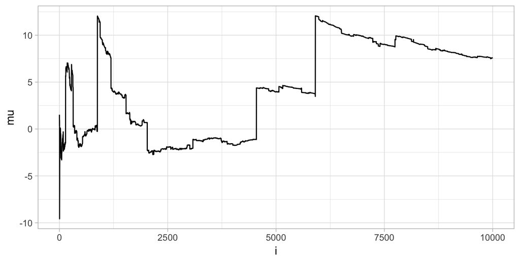

```r
D <-
  data_frame(
    i = 1:1e4,
    y = rcauchy(1e4, 0, 5),
    mu = cumsum(y) / i
  )
gf_line(mu ~ i, data = D)
```

#### R Code 8.17

```r
y <- rnorm(100, mean = 0, sd = 1)
```

#### R Code 8.18

```r
m8.4 <- map2stan(
  alist(y ~ dnorm(mu, sigma),
        mu <- a1 + a2,
        sigma ~ dcauchy(0, 1)),
  data = list(y = y),
  start = list(a1 = 0, a2 = 0, sigma = 1),
  chains = 2, cores = 2,
  iter = 4000,
  warmup = 1000
)
```

[output not shown]

```
## Computing WAIC
```

```
## Constructing posterior predictions
```

[output not shown]

```r
precis(m8.4)
```

```
##           Mean StdDev lower 0.89 upper 0.89 n_eff Rhat
## a1     1639.19 802.36     484.04    2913.38     5 1.49
## a2    -1639.08 802.36   -2913.22    -483.92     5 1.49
## sigma     0.98   0.06       0.89       1.07    39 1.03
```

#### R Code 8.19

```r
m8.5 <- map2stan(
  alist(
    y ~ dnorm(mu, sigma),
    mu <- a1 + a2,
    a1 ~ dnorm(0, 10),
    a2 ~ dnorm(0, 10),
    sigma ~ dcauchy(0, 1)
  ),
  data = list(y = y),
  start = list(a1 = 0, a2 = 0, sigma = 1),
  chains = 2, cores = 2,
  iter = 4000, warmup = 1000
)
```

[output not shown]

```
## Computing WAIC
```

```
## Constructing posterior predictions
```

[output not shown]

```r
precis(m8.5)
```

```
##       Mean StdDev lower 0.89 upper 0.89 n_eff Rhat
## a1    0.11   7.10     -11.15      11.41  1473    1
## a2    0.00   7.10     -10.88      11.70  1474    1
## sigma 0.97   0.07       0.86       1.08  2214    1
```

#### R Code 8.20

```r
mp <-
  map2stan(
    alist(a ~ dnorm(0, 1), b ~ dcauchy(0, 1)),
    data = list(y = rep(1,10)),
    start = list(a = 0, b = 0),
    iter = 1e4, warmup = 100,
    WAIC = FALSE
  )
```

[output not shown]

#### R Code 8.21

Simulating height and leg length.

```r
N <- 100                            # number of individuals
Legs <-
  data_frame(
    height = rnorm(N, 10, 2),          # sim total height of each
    leg_prop = runif(N, 0.4, 0.5),     # leg as proportion of height
    leg_left  = leg_prop * height + rnorm(N, 0, 0.02),
    leg_right = leg_prop * height + rnorm(N, 0, 0.02)
  )
```

#### R Code 8.22

```r
m5.8s <- map2stan(
  alist(
    height ~ dnorm(mu, sigma),
    mu <- a + bl * leg_left + br * leg_right,
    a ~ dnorm(10, 100),
    bl ~ dnorm(2, 10),
    br ~ dnorm(2, 10),
    sigma ~ dcauchy(0, 1)
  ),
  data = Legs,
  chains = 4, cores = 4,
  start = list(
    a = 10, bl = 0,
    br = 0, sigma = 1
  )
)
```

[output not shown]

```
## Computing WAIC
```

```
## Constructing posterior predictions
```

[output not shown]

```r
m5.8s2 <- map2stan(
  alist(
    height ~ dnorm(mu, sigma),
    mu <- a + bl * leg_left + br * leg_right,
    a ~ dnorm(10, 100),
    bl ~ dnorm(2, 10),
    br ~ dnorm(2, 10) & T[0, ],
    sigma ~ dcauchy(0, 1)
  ),
  data = Legs,
  chains = 4, cores = 4,
  start = list(
    a = 10, bl = 0,
    br = 0, sigma = 1
  )
)
```

[output not shown]

```
## Computing WAIC
```

```
## Constructing posterior predictions
```

[output not shown]